# DAX Applicant Homework Report

Mohammad Adi Amirudin

3/28/2021

## R Markdown

This is an R Markdown document of DAX Applicant Homework submitted by Mohammad Adi Amirudin. The full documentation of this applicant homework can be accessed via https://drive.google.com/drive/folders/1LI9ZpUVW4ZjlPqp6b4Yg5UYELy8rYUPj?usp=sharing, or simply access through the documents files here:

1. **Applicant homework materials:** https://drive.google.com/drive/folders/1-obvrv31h0jwDaUP1opjEcq0_1HIA5zO?usp=sharing
2. **R Script:** https://drive.google.com/file/d/1ZYKXaf8JIBneDwAlsL9QHfc6s7Nw7kGi/view?usp=sharing
3. **Applicant homework report (pdf):** https://drive.google.com/drive/folders/1pQLlXVATgx2-Oe4pq5sE6sCXkD6oIt8I?usp=sharing

## DAX Homework for Data Analyst Candidate

### Subject:

Data Analysis and Develop Prediction Model

### Details:

1. Kindly analyze and visualize sample data. “Data.csv”. Kindly show us summary of some findings based on your analysis.
2. Kindly develop prediction model to predict the score of Math by using Python or R. You need to use “Data.csv” as sample data. Based on other scores, Physics, Science and Statistics, you need to predict the scores of Math.

### Deliverables:

1. Data Analysis and summary of findings. ( Better have some visualizations for analysis)
2. Detailed explanation of your developed model:
   - Why do you choose that model?
   - How do you proceed the model development? Please explain about your process.
   - How do you check accuracy of that model?
3. Please explain about your model features. Good parts and improvable parts.
4. Actual Python or R source code.

## Deliverable 1: Data Analysis & Summary of Findings

### Data Preparation

The first step to analyze the data is to import the data from the location directory first, then wI created backup for the data, while also load some R packages that will be useful in conducting data analysis, specifically related to continuous dataset, as seen in data.csv:

**Importing Data**

```r
Data <- read.csv("D:/Data Analysis/DAX Homework/SourceFiles/Data.csv")
```

**Creating Backup**

```r
DAXdata <- Data
attach(DAXdata)
```

The data analysis will be done in `DAXdata` data.frame that is a duplicate from data.frame from Data.csv.

**Loading Useful R Packages**

```r
library(psych)
library(caret)
library(dplyr)
library(ggplot2)
library(GGally)
library(glmnet)
library(lars)
library(elasticnet)
library(jtools)
library(knitr)
library(png)
```

For packages help, call the command `help(package_name)` for instance, `help(caret)`.

### Data Analysis

**The Data at A Glance**

```r
glimpse(DAXdata)
```

```
## Rows: 466
## Columns: 4
## $ Pysics     <int> 64, 74, 60, 84, 80, 75, 66, 77, 70, 89, 73, 78, 67, 80, 72,~
## $ Science    <int> 67, 74, 59, 88, 88, 68, 59, 71, 71, 84, 76, 74, 63, 81, 75,~
## $ Statistics <int> 69, 63, 55, 89, 78, 68, 55, 66, 60, 80, 69, 63, 67, 83, 73,~
## $ Math       <int> 68, 67, 57, 91, 82, 63, 65, 73, 67, 85, 82, 67, 57, 74, 83,~
```

**Illustrating the data types, values, observation count and variable count.** The data consist of arrays of columns and rows (4 columns and 466 rows in total), with every observations categorized as integer, meaning that the data is a **continuous data**.

**Summary Statistics**

```r
summary(DAXdata)
```

```
##      Pysics         Science        Statistics          Math
##  Min.   : 0.00   Min.   : 0.00   Min.   : 22.00   Min.   :22.00
##  1st Qu.:66.00   1st Qu.:66.00   1st Qu.: 66.25   1st Qu.:67.00
##  Median :74.00   Median :74.00   Median : 74.00   Median :74.00
##  Mean   :71.74   Mean   :72.81   Mean   : 73.68   Mean   :74.54
##  3rd Qu.:82.00   3rd Qu.:83.00   3rd Qu.: 83.00   3rd Qu.:83.00
##  Max.   :99.00   Max.   :99.00   Max.   :100.00   Max.   :99.00
```

**Illustrating the summary statistics of the data.** Here we can observe the minimum and maximum value of each variable, 1st quantile of the data (one fourth way along from the first observation to the last observation), the 3rd quantile of the data (three fourth way along the way from the first observation to the last observation), mean (average value of each variables), and median.

**Correlation Between Variables (Using Pearson Correlation Coefficient)**

```r
cor(DAXdata)
```

```
##                Pysics    Science Statistics       Math
## Pysics     1.00000000 0.08769228  0.0750317 0.05250237
## Science    0.08769228 1.00000000  0.1633659 0.15428389
## Statistics 0.07503170 0.16336588  1.0000000 0.22706189
## Math       0.05250237 0.15428389  0.2270619 1.00000000
```

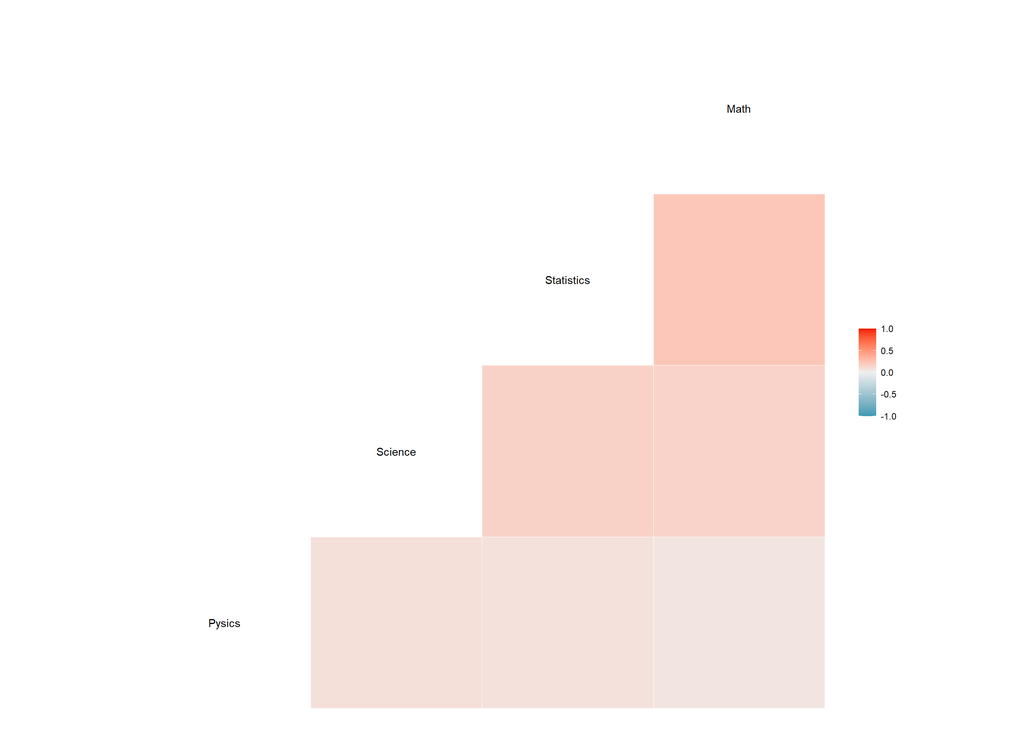

```r
ggcorr(DAXdata, method = c("pairwise","pearson"))
```

**Both the table and the graphic are llustrating the relationship between variables, i.e., correlogram.** Correlogram value at 1.00000 refers to strongly positive correlated, while 0.00000 refers to strongly uncorrelated, value -1.00000 refers to strongly negative correlated.

In this correlogram, related to Math (dependent variable/variable of interest), variable `Statistics` (0.22706189) has the highest correlation with Math, while `Science` (0.15428389) and `Pysics` (0.05250237) follows respectively. It is also worth noting that correlogram only depicts correlation between variables using covariance of two variables, divided by the product of their standard deviations, **thus further examination of the relationship between variables needs to be addressed.**

The correlation value also serves as a basis of autocorrelation checking in linear regression, meaning that if the value among independent variables (Pysics, Statistics, Science) accounted more than 0.80000 the regression model will suffers from autocorrelation problem, producing bias estimation. **Based on the result, the data is not suffering an autocorrelation problem.**

**Data Distribution & Correlation Matrix**

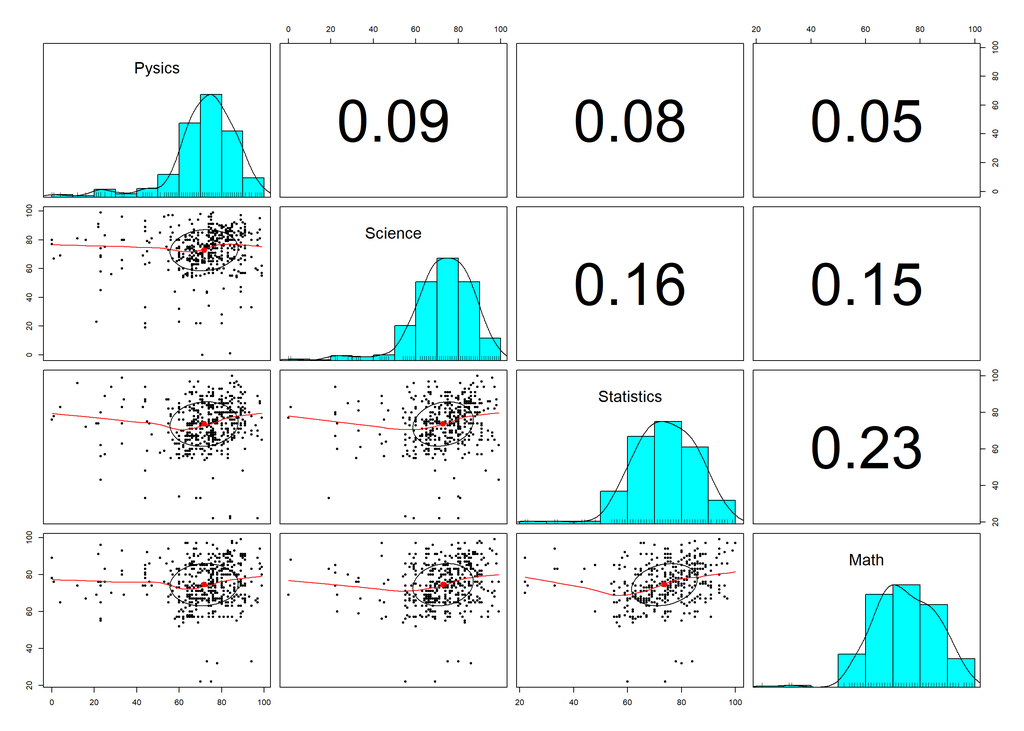

```r
pairs.panels(DAXdata)
```

**Illustrating the distribution of the data, as well as the correlation between each variables.** The diagonal graph are the distribution of the data in each variables, depicted with histogram. Above the diagonal is the pearson correlation matrix, rounded to 0.00 (2 points behind decimal).

Below the diagonal are the `scatterplots` of the variables with `correlation ellipse`. The dot at the center of the ellipse indicates the point of the mean value for the `x axis variable` and `y axis variable`. The correlation between the two variables is indicated by the shape of the ellipse; **the more it is stretched, the stronger the correlation**. An almost perfectly round oval, as with `Pysics` and `Math`, indicates a very weak correlation (in this case 0.05).

**Multiple Linear Regression**

```r
linearreg <- lm(Math ~ ., data = DAXdata)
summary(linearreg)
```

```
##
## Call:
## lm(formula = Math ~ ., data = DAXdata)
##
## Residuals:
##     Min      1Q  Median      3Q     Max
## -50.881  -7.593  -0.232   7.920  26.605
##
## Coefficients:
##             Estimate Std. Error t value Pr(>|t|)
## (Intercept) 52.06091    4.26124  12.217  < 2e-16 ***
## Pysics       0.01902    0.03222   0.590  0.55529
## Science      0.09474    0.03659   2.589  0.00992 **
## Statistics   0.19295    0.04282   4.506 8.37e-06 ***
## ---
## Signif. codes:  0 '***' 0.001 '**' 0.01 '*' 0.05 '.' 0.1 ' ' 1
##
## Residual standard error: 11.07 on 462 degrees of freedom
## Multiple R-squared:  0.06637,    Adjusted R-squared:  0.06031
## F-statistic: 10.95 on 3 and 462 DF,  p-value: 5.872e-07
```

**Goodness-of-Fit Evaluation (Residual Plotting)**

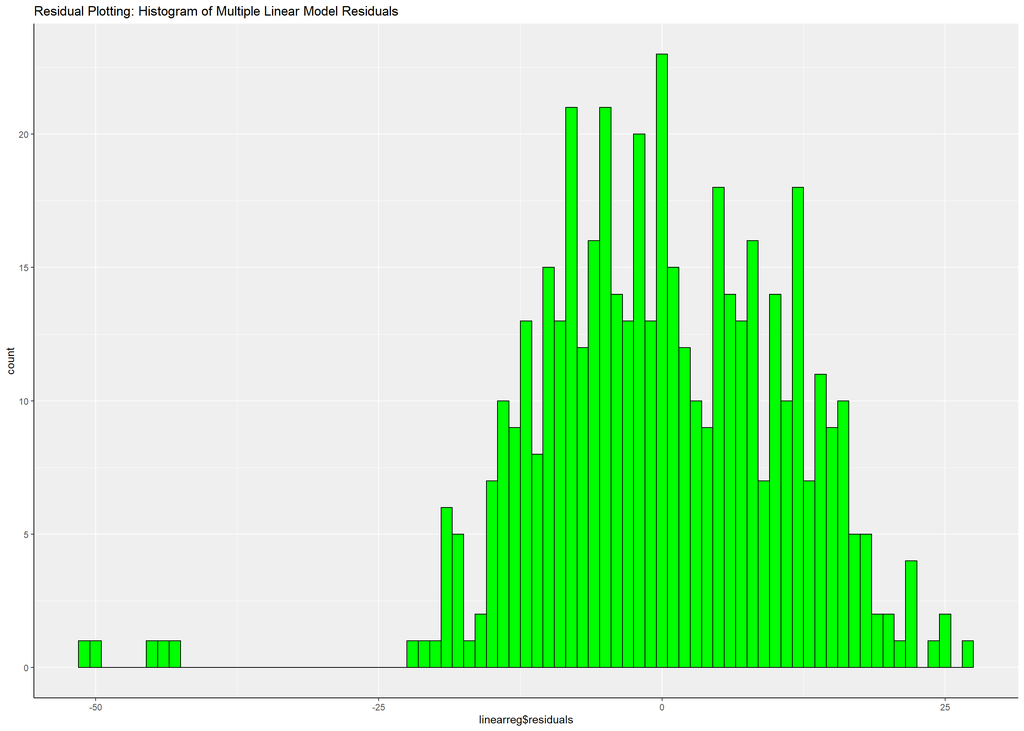

```r
ggplot(data=DAXdata, aes(linearreg$residuals)) +
geom_histogram(binwidth = 1, color = "black", fill = "green") +
theme(panel.background = element_rect(fill = "#efefef"),
axis.line.x=element_line(),
axis.line.y=element_line()) +
ggtitle("Residual Plotting: Histogram of Multiple Linear Model Residuals")
```

The residual plotting shows that while the distribution tends to congregate around 0, the distribution of the residuals seems to be spread around -25 and 25, thus perpetuate the low R-squared value.

I did a plotting for each independent variable to dependent variable residual effect to examine the state of individual variable residuals, the graphic are as presented as below:

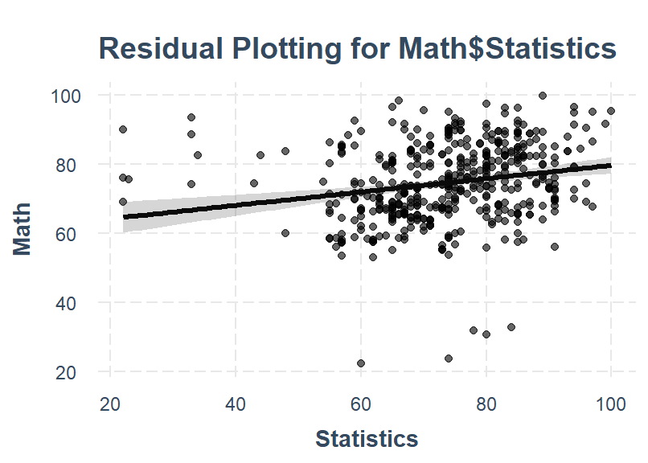

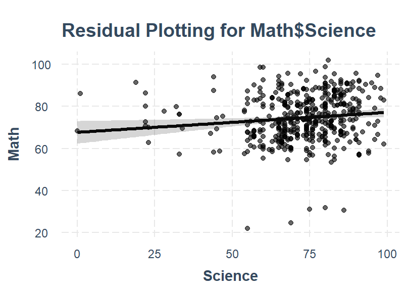

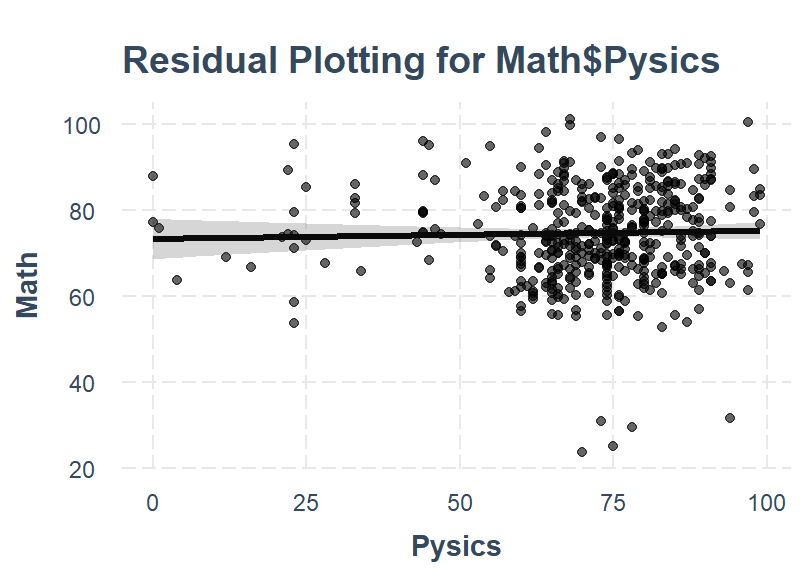

## Deliverables 2: Detailed Explanation of The Developed Model

### Model Selection | Why Choosing Multiple Linear Regression Prediction Model?

There are plenty of model that we can select in order to obtain the optimal result of prediction, the list of the models can be accessed in here: https://docs.microsoft.com/en-us/azure/machine-learning/algorithm-cheat-sheet In a search for the optimal prediction model, the following characteristics needs to be addressed:

1. Data types: *Continuous*
2. Dependent & independent variable relationship: *Linear*
3. Output expected: *Numerical, continuous.*
4. Number of predictors: *More than 1*
5. Include time variable: *No*

With the reference of the characteristics in `Data.csv`, several possible models are listed, namely;

1. Linear Regression Prediction
2. **Multiple Linear Regression Prediction**
3. Logistic Linear Prediction
4. Decision Tree Prediction
5. Random Forest Prediction

The selected model is **Multiple Regression Prediction Model** as a result of the following considerations:

1. **The data characteristics** fitted well, linear prediction only accounted for 1 predictor, while multiple linear prediction can be assessed into more than 1 predictors (`Science`, `Pysics`, `Statistics`).
2. The expected output is numerical, continuous output, while logistic linear, decision tree and random forest prediction can be assessed into continuous dataset, they all also used in predicting values which expected output is bayesian output and other. **The linear relationship between variables examined through previous tests comply with multiple linear regression model**, making its ideal in comparison with decision tree, logistic linear, and random forest prediction model.
3. **Close/similar statistical result from `train` data and the actual data.** I created a dataset using 70% of `Data.csv` as a reference for the `train data.frame` using random sampling. the result resemble the actual data, with full disclosure of summary statistics and regression results from `train` and `DAXdata` (actual dataset from `Data.csv`) are presented as below:

**Summary Statistics | Actual Dataset (`DAXdata` taken from `Data.csv`)**

```
##      Pysics         Science        Statistics          Math
##  Min.   : 0.00   Min.   : 0.00   Min.   : 22.00   Min.   :22.00
##  1st Qu.:66.00   1st Qu.:66.00   1st Qu.: 66.25   1st Qu.:67.00
##  Median :74.00   Median :74.00   Median : 74.00   Median :74.00
##  Mean   :71.74   Mean   :72.81   Mean   : 73.68   Mean   :74.54
##  3rd Qu.:82.00   3rd Qu.:83.00   3rd Qu.: 83.00   3rd Qu.:83.00
##  Max.   :99.00   Max.   :99.00   Max.   :100.00   Max.   :99.00
```

**Summary Statistics | Train Dataset (`train` dataset created from random sampling of 70% `DAXdata`)**

```
##      Pysics         Science        Statistics        Math
##  Min.   : 0.00   Min.   : 0.00   Min.   :22.0   Min.   :22.00
##  1st Qu.:65.00   1st Qu.:66.00   1st Qu.:67.0   1st Qu.:67.00
##  Median :74.00   Median :74.00   Median :74.0   Median :74.00
##  Mean   :70.91   Mean   :72.44   Mean   :73.4   Mean   :74.11
##  3rd Qu.:81.75   3rd Qu.:82.00   3rd Qu.:82.0   3rd Qu.:82.00
##  Max.   :99.00   Max.   :98.00   Max.   :99.0   Max.   :97.00
```

**Linear Regression Result | Actual Dataset (`DAXdata` taken from `Data.csv`)**

```
##
## Call:
## lm(formula = Math ~ ., data = DAXdata)
##
## Residuals:
##     Min      1Q  Median      3Q     Max
## -50.881  -7.593  -0.232   7.920  26.605
##
## Coefficients:
##             Estimate Std. Error t value Pr(>|t|)
## (Intercept) 52.06091    4.26124  12.217  < 2e-16 ***
## Pysics       0.01902    0.03222   0.590  0.55529
## Science      0.09474    0.03659   2.589  0.00992 **
## Statistics   0.19295    0.04282   4.506 8.37e-06 ***
## ---
## Signif. codes:  0 '***' 0.001 '**' 0.01 '*' 0.05 '.' 0.1 ' ' 1
##
## Residual standard error: 11.07 on 462 degrees of freedom
## Multiple R-squared:  0.06637,    Adjusted R-squared:  0.06031
## F-statistic: 10.95 on 3 and 462 DF,  p-value: 5.872e-07
```

**Linear Regression Result | Train Dataset (`train` dataset created from random sampling of 70% `DAXdata`)**

```
##
## Call:
## lm(formula = Math ~ ., data = train)
##
## Residuals:
##     Min      1Q  Median      3Q     Max
## -50.438  -7.591  -0.603   7.820  26.213
##
## Coefficients:
##             Estimate Std. Error t value Pr(>|t|)
## (Intercept) 52.84041    4.74937  11.126  < 2e-16 ***
## Pysics       0.01350    0.03512   0.385 0.700834
## Science      0.10113    0.04173   2.424 0.015916 *
## Statistics   0.17689    0.04976   3.555 0.000434 ***
## ---
## Signif. codes:  0 '***' 0.001 '**' 0.01 '*' 0.05 '.' 0.1 ' ' 1
##
## Residual standard error: 10.56 on 322 degrees of freedom
## Multiple R-squared:  0.06833,    Adjusted R-squared:  0.05965
## F-statistic: 7.872 on 3 and 322 DF,  p-value: 4.394e-05
```

### Model Specification & Attributes:

1. The prediction model is **Multiple Linear Regression Prediction**.
2. The model uses **train control function preprocessing** `trControl <- preProcess(c(independent_variables), train, method = c("center", "scale"))`, in which scaling the independent variables to the means of the variables and center it.
3. The model later imposed with *regularization through dummy variables*, creating a model matrix using dummy variables to make the independent variable (`Statistics`, `Pysics`, `Science`) becoming a factor value to be able to process **Ridge Regression** and **Lasso Regression** models.
4. **Ridge Regression & Lasso Regression** prediction models are also introduced in the prediciton model to control the loss function and modified it to minimize the complexity of the model.
5. **Ridge Regression & Lasso Regression** are predicted with `optimal lambdas` selected for each of the prediction model.

## Model Development Process | How Do You Proceed The Model Development?

### Model Development Process | Diagram

The following **flowchart diagram** represented the process in which I took in order to develop the prediction model.

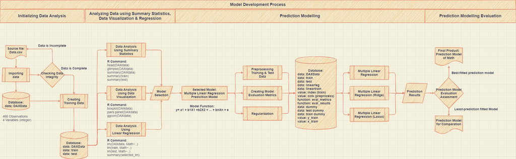

### Model Development Process | Steps

**A. Importing Dataset & Library Package, Data Integrity Checking**

```r
Data <- read.csv("D:/Data Analysis/DAX Homework/SourceFiles/Data.csv")
## Creating backup
DAXdata <- Data
attach(DAXdata)

## Packages Used
library(tinytex)
library(psych)
#...
library(knitr)
library(png)
## As seen in Deliverable 1: Data Preparation
```

For full process of dataset import, library package and data integrity checking, please refers to section **Deliverable 1: Data Preparation**.

**B. Data Integrity Checking**

```r
## Make sure VARIABLES has no missing value:
stopifnot(!any(is.na(Math)))
stopifnot(!any(is.na(Science)))
stopifnot(!any(is.na(Pysics)))
stopifnot(!any(is.na(Statistics)))
#The results didn't fetch any issue, data has no missing value.

## Make sure VARIABLES is NUMERIC
stopifnot(is.numeric(Math))
stopifnot(is.numeric(Statistics))
stopifnot(is.numeric(Science))
stopifnot(is.numeric(Pysics))
glimpse(DAXdata)
```

```
## Rows: 466
## Columns: 4
## $ Pysics     <int> 64, 74, 60, 84, 80, 75, 66, 77, 70, 89, 73, 78, 67, 80, 72,~
## $ Science    <int> 67, 74, 59, 88, 88, 68, 59, 71, 71, 84, 76, 74, 63, 81, 75,~
## $ Statistics <int> 69, 63, 55, 89, 78, 68, 55, 66, 60, 80, 69, 63, 67, 83, 73,~
## $ Math       <int> 68, 67, 57, 91, 82, 63, 65, 73, 67, 85, 82, 67, 57, 74, 83,~
```

```r
#data is NUMERIC (no error message fetched), glimpse data describe as integer.
```

**C. Data Partitioning**

```r
set.seed(100)
index <- sample(1:nrow(DAXdata), 0.7*nrow(DAXdata))
train <- DAXdata[index,] # Create the training data
test <- DAXdata[-index,] # Create the test data
```

**D. Analyzing Data Using Summary Statistics, Visualization & Regression Result**

```r
#Data Analysis Using Summary Statistics
summary(DAXdata)
```

```
##      Pysics         Science        Statistics          Math
##  Min.   : 0.00   Min.   : 0.00   Min.   : 22.00   Min.   :22.00
##  1st Qu.:66.00   1st Qu.:66.00   1st Qu.: 66.25   1st Qu.:67.00
##  Median :74.00   Median :74.00   Median : 74.00   Median :74.00
##  Mean   :71.74   Mean   :72.81   Mean   : 73.68   Mean   :74.54
##  3rd Qu.:82.00   3rd Qu.:83.00   3rd Qu.: 83.00   3rd Qu.:83.00
##  Max.   :99.00   Max.   :99.00   Max.   :100.00   Max.   :99.00
```

```r
#Data Analysis Using Visualization

#Visualization for Model Residual (Base Data)

#Visualization for Individual Model Residual

#Data Analysis Using Linear Regression
```

For full process of Analyzing Data Using Summary Statistics, Visualization & Regression Result and its results and analysis please refers to section: **Deliverable 1: Data Analysis**.

**E. Model Selection**

```r
lineartrain <- lm(Math ~ ., data = train)
summary(lineartrain)
```

```
##
## Call:
## lm(formula = Math ~ ., data = train)
##
## Residuals:
##     Min      1Q  Median      3Q     Max
## -50.438  -7.591  -0.603   7.820  26.213
##
## Coefficients:
##             Estimate Std. Error t value Pr(>|t|)
## (Intercept) 52.84041    4.74937  11.126  < 2e-16 ***
## Pysics       0.01350    0.03512   0.385 0.700834
## Science      0.10113    0.04173   2.424 0.015916 *
## Statistics   0.17689    0.04976   3.555 0.000434 ***
## ---
## Signif. codes:  0 '***' 0.001 '**' 0.01 '*' 0.05 '.' 0.1 ' ' 1
##
## Residual standard error: 10.56 on 322 degrees of freedom
## Multiple R-squared:  0.06833,    Adjusted R-squared:  0.05965
## F-statistic: 7.872 on 3 and 322 DF,  p-value: 4.394e-05
```

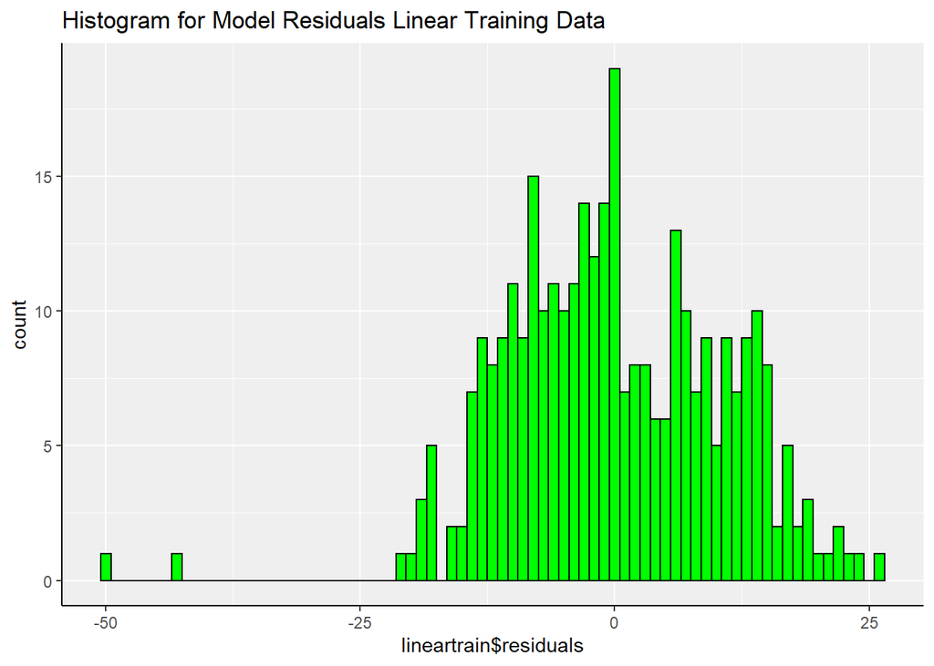

```r
ggplot(data=train, aes(lineartrain$residuals)) +
  geom_histogram(binwidth = 1, color = "black", fill = "green") +
  theme(panel.background = element_rect(fill = "#efefef"),
        axis.line.x=element_line(),
        axis.line.y=element_line()) +
  ggtitle("Histogram for Model Residuals Linear Training Data")
```

For full process of model selection, please refers to **Deliverable 2: Model Selection | Why Choosing Multiple Linear Regression Prediction Model?** section.

**F. Creating Preprocessing Independent Variables**

```r
cols = c('Pysics', 'Science', 'Statistics')

pre_proc_val <- preProcess(train[,cols], method = c("center", "scale"))

train[,cols] = predict(pre_proc_val, train[,cols])
test[,cols] = predict(pre_proc_val, test[,cols])

summary(train) #Scaling and centering numeric feature
```

```
##      Pysics           Science          Statistics            Math
##  Min.   :-4.2269   Min.   :-5.0287   Min.   :-4.26809   Min.   :22.00
##  1st Qu.:-0.3523   1st Qu.:-0.4468   1st Qu.:-0.53157   1st Qu.:67.00
##  Median : 0.1841   Median : 0.1086   Median : 0.04967   Median :74.00
##  Mean   : 0.0000   Mean   : 0.0000   Mean   : 0.00000   Mean   :74.11
##  3rd Qu.: 0.6461   3rd Qu.: 0.6640   3rd Qu.: 0.71394   3rd Qu.:82.00
##  Max.   : 1.6743   Max.   : 1.7748   Max.   : 2.12551   Max.   :97.00
```

```r
lineartrain <- lm(Math ~ ., data = train)
summary(lineartrain)
```

```
##
## Call:
## lm(formula = Math ~ ., data = train)
##
## Residuals:
##     Min      1Q  Median      3Q     Max
## -50.438  -7.591  -0.603   7.820  26.213
##
## Coefficients:
##             Estimate Std. Error t value Pr(>|t|)
## (Intercept)  74.1074     0.5851 126.665  < 2e-16 ***
## Pysics        0.2266     0.5892   0.385 0.700834
## Science       1.4567     0.6010   2.424 0.015916 *
## Statistics    2.1304     0.5992   3.555 0.000434 ***
## ---
## Signif. codes:  0 '***' 0.001 '**' 0.01 '*' 0.05 '.' 0.1 ' ' 1
##
## Residual standard error: 10.56 on 322 degrees of freedom
## Multiple R-squared:  0.06833,    Adjusted R-squared:  0.05965
## F-statistic: 7.872 on 3 and 322 DF,  p-value: 4.394e-05
```

This code will run a preprocessing process in which observations values for `Science`, `Pysics`, and `Statistics` are centered and scaled (value changed with respects to mean value and center it, making value as much as mean = 0 and other values are +/- to the mean value respectfully). **This process is required, otherwise, they may adversely influence the modeling process.**

**G. Creating Model Evaluation Metrics**

```r
# For Multiple Linear Regression
eval_metrics <- function(model, df, predictions, target) {
  resids = df[,target] - predictions
  resids2 = resids**2
  N = length(predictions)
  r2 = as.character(round(summary(model)$r.squared, 2))
  adj_r2 = as.character(round(summary(model)$adj.r.squared, 2))
  print("Adjusted R-Squared")
  print(adj_r2) #Adjusted R-squared
  print("RMSE")
  print(as.character(round(sqrt(sum(resids2)/N), 2))) #RMSE
}

# For Ridge and Lasso Regression
eval_results <- function(true, predicted, df) {
  SSE <- sum((predicted - true)^2)
  SST <- sum((true - mean(true))^2)
  R_square <- 1 - SSE / SST
  RMSE = sqrt(SSE/nrow(df))
  # Model performance metrics
  data.frame(
    RMSE = RMSE,
    Rsquare = R_square
  )
  }
```

**H. Regularization**

```r
# Creating Training Data Matrices for Multiple Linear Regression Model with Regularization (Ridge Method and Lasso Method)
cols_reg = c('Pysics', 'Science', 'Statistics', 'Math')
dummies <- dummyVars(Math ~., data = DAXdata[,cols_reg])
train_dummies = predict(dummies, newdata = train[,cols_reg])
test_dummies = predict(dummies, newdata = test[,cols_reg])
print(dim(train_dummies)); print(dim(test_dummies))
```

```
## [1] 326   3
```

```
## [1] 140   3
```

```r
x = as.matrix(train_dummies)
y_train = train$Math

x_test = as.matrix(test_dummies)
y_test = test$Math

# Finding The Best Hyperparameter for Optimal Regularization Result
## Hyperparameter tuning (lambda) using package(caret):
## For both Ridge and Lasso Regression:
fitControl <- trainControl(method = "repeatedcv",
                           number = 10,     # number of folds
                           repeats = 10,    # repeated ten times
                           search = "random") #searching for optimal lambda
## Hyperparameter tuning (lambda) using package(glmnet):
## Ridge Regression:
lambdas <- 10^seq(2, -3, by = -.1)
cv_ridge <- cv.glmnet(x, y_train, alpha = 0, lambda = lambdas)
optimal_lambda <- cv_ridge$lambda.min
optimal_lambda
```

```
## [1] 1.995262
```

```r
## Lasso Regression:
lambdas <- 10^seq(2, -3, by = -.1)
lasso_reg <- cv.glmnet(x, y_train, alpha = 1, lambda = lambdas,
                      #Setting alpha to 1 makes it perform lasso regression
                      standardize = TRUE, nfolds = 5)
lambda_best <- lasso_reg$lambda.min
lambda_best
```

```
## [1] 0.2511886
```

Linear regression algorithm works by selecting coefficients for each independent variable that minimizes a loss function. However, if the coefficients are large, they can lead to over-fitting on the training dataset, and such a model will not generalize well on the unseen test data.**To overcome this shortcoming, we’ll do regularization**, which penalizes large coefficients.

These codes above explaining the regularization process. The process involved in finding the best hyperparameter (the best-fitted model tested on lambda sequences) for `Ridge` and `Lasso` Regression.

I run codes by using 2 package, namely `package(caret)` and `package(glmnet)` while `caret` package do the lambda/ hyperparameter tuning process automatically, the `glmnet` package required to specify an additional information regarding the process, such as the needs in creating values and data for lambda.

**J. Regression Models**

I employ linear regression with 3 models:

**1. Multiple Linear Regression Model** **2. Multiple Linear Regression Model(With Ridge method for regularization)** **2. Multiple Linear Regression Model(With Lasso method for regularization)**

The following codes are the operation of the regression:

```r
## Using caret Package
## Linear Regression
    library(caret)
    linearcrt <- train(Math ~.,
                       data = DAXdata,
                       method = "lm")
## Ridge Regression
    ridgecrt <- train(Math ~.,
                      data = DAXdata,
                      method = "ridge",
                      trControl = fitControl,
                      preProcess = c('scale','center'),
                      na.action = na.omit)
## Lasso Regression
    lassocrt <- train(Math ~ .,
                      data = DAXdata,
                      method = "lasso",
                      trControl = fitControl,
                      preProcess = c('scale', 'center'),
                      na.action = na.omit)

## Using glmnet Package
## Linear Regression
    lineartrain <- lm(Math ~ ., data = train)

## Ridge Regression
    ridge_reg <- glmnet(x, y_train, nlambda = 25, alpha = 0,
                       #Setting alpha to 0 makes it perform ridge regression
                       family = 'gaussian', lambda = optimal_lambda)

#Lasso Regression using optimal lambda
    lasso_model <- glmnet(x, y_train, alpha = 1, lambda = lambda_best,
                          standardize = TRUE)
```

The result of the regression is as follows:

```r
linearcrt
```

```
## Linear Regression
##
## 466 samples
##   3 predictor
##
## No pre-processing
## Resampling: Bootstrapped (25 reps)
## Summary of sample sizes: 466, 466, 466, 466, 466, 466, ...
## Resampling results:
##
##   RMSE      Rsquared    MAE
##   11.14361  0.06576609  8.841422
##
## Tuning parameter 'intercept' was held constant at a value of TRUE
```

```r
ridgecrt
```

```
## Ridge Regression
##
## 466 samples
##   3 predictor
##
## Pre-processing: scaled (3), centered (3)
## Resampling: Cross-Validated (10 fold, repeated 10 times)
## Summary of sample sizes: 421, 419, 420, 420, 418, 419, ...
## Resampling results across tuning parameters:
##
##   lambda        RMSE      Rsquared    MAE
##   0.0001987381  11.02742  0.08423147  8.749566
##   0.0323214442  11.02739  0.08428748  8.748552
##   7.5537410554  11.04143  0.08522659  8.728531
##
## RMSE was used to select the optimal model using the smallest value.
## The final value used for the model was lambda = 0.03232144.
```

```r
lassocrt
```

```
## The lasso
##
## 466 samples
##   3 predictor
##
## Pre-processing: scaled (3), centered (3)
## Resampling: Cross-Validated (10 fold, repeated 10 times)
## Summary of sample sizes: 420, 420, 420, 420, 419, 418, ...
## Resampling results across tuning parameters:
##
##   fraction   RMSE      Rsquared    MAE
##   0.3558943  11.12132  0.07514400  8.907078
##   0.8415552  11.00937  0.08299054  8.760546
##   0.8597088  11.00902  0.08299616  8.757092
##
## RMSE was used to select the optimal model using the smallest value.
## The final value used for the model was fraction = 0.8597088.
```

As we can see, the codes above fetch the RMSE and R-squared for every regression results. Next we will make a prediction using `train` data and `test` data that based on the sample of the actual dataset.

**K. Prediction Model**

```r
### Using manual method & glmnet Package
    #Prediction from linear prediction
    predictlmtrain <- predict(lineartrain, newdata = train)
    predictlmtest <- predict(lineartrain, newdata = test)

    #Prediction from ridge prediction
    predictridgetrain <- predict(ridge_reg, s = optimal_lambda, newx = x)
    predictridgetest <- predict(ridge_reg, s = optimal_lambda, newx = x_test)

    #Prediction from lasso prediction
    predictlassotrain <- predict(lasso_model, s = lambda_best, newx = x)
    predictlassotest <- predict(lasso_model, s = lambda_best, newx = x_test)

### Using caret Package
    #Prediction from linear prediction
    predictlmcrt <- predict(linearcrt, DAXdata)

    #Prediction from ridge prediction
    predictridgecrt <- predict(ridgecrt, DAXdata)

    #Prediction from ridge prediction
    predictlassocrt <- predict(lassocrt, DAXdata)
```

**L. Model Evaluation Metrics**

```r
## Linear Prediction
eval_metrics(lineartrain, train, predictlmtrain, target = 'Math')
```

```
## [1] "Adjusted R-Squared"
## [1] "0.06"
## [1] "RMSE"
## [1] "10.5"
```

```r
eval_metrics(lineartrain, test, predictlmtest, target = 'Math')
```

```
## [1] "Adjusted R-Squared"
## [1] "0.06"
## [1] "RMSE"
## [1] "12.19"
```

```r
## Ridge Prediction
eval_results(y_train, predictridgetrain, train)
```

```
##       RMSE    Rsquare
## 1 10.50534 0.06713337
```

```r
eval_results(y_test, predictridgetest, test)
```

```
##      RMSE    Rsquare
## 1 12.2107 0.04773909
```

```r
## Lasso Prediction
eval_results(y_train, predictlassotrain, train)
```

```
##       RMSE    Rsquare
## 1 10.50591 0.06703285
```

```r
eval_results(y_test, predictlassotest, test)
```

```
##       RMSE    Rsquare
## 1 12.21141 0.04762883
```

Further explanation of the model evaluation metrics are included in the next section: **Model Validation | How to Check The Model Accuracy?**

### Model Validation | How to Check The Model Accuracy?

Table below are the summarization of **RMSE and R-squared of the models that’s being used in order to validate this prediction**, we compare the value of RMSE and R-squared to make sure that we chooses the best-fitted model.

**RMSE and R-Squared table**

[output not shown]

As we can see, the splitting `test` and `train` method produce a somewhat similar value of **RMSE** and **R-squared** to actual linear regression, with differences differs from 0.01 to 0.002 in **R-squared** and 1.2 to 0.6 in **RMSE**.

So the best-fitted model to choose is **Multiple Linear Regression Prediction Model**.

Prediction result on the best-fitted model: **Multiple Linear Regression Prediction Model**

```r
predictlmcrt
```

[output not shown]

[output cut: 63 more lines]

```
## 72.57659 72.43999 71.24933 77.22233 77.01986 73.39281 72.18650 73.27721
##      417      418      419      420      421      422      423      424
## 73.14049 77.63746 76.05487 74.88625 71.17466 75.85588 76.15273 74.89911
##      425      426      427      428      429      430      431      432
## 75.85576 73.96415 78.89573 73.83833 75.34706 71.45110 76.38419 78.90686
##      433      434      435      436      437      438      439      440
## 72.40543 72.59213 71.40147 77.26037 77.21004 73.24067 72.03436 72.95392
##      441      442      443      444      445      446      447      448
## 73.23557 78.05585 75.75059 74.44884 70.83234 76.31230 75.94354 74.57582
##      449      450      451      452      453      454      455      456
## 76.44531 73.52674 70.17437 72.89825 78.71912 76.62434 72.36867 72.45205
##      457      458      459      460      461      462      463      464
## 74.94446 72.72525 78.49045 74.97472 72.45900 73.10674 74.96660 75.47020
##      465      466
## 75.82712 76.31148
```

## Deliverable 3: Model Features

### Improvable Parts

While the selected model are **Multiple Regression Linear Prediction Model** and not using `Ridge` or `Lasso` regularization method, the use of `Ridge` and `Lasso` method in the regularization of the data may serve a good purpose in this kind of data (small number of variable/predictor, linear regression) to ensure that the prediction didn’t suffer from overfitting.

## Deliverable 4: Actual Python/R Source Code

This data analysis is processed using RStudio tool (Version 1.4.1106), the R source code of this data analysis is also attached in the file.rar, or can be accessible from: https://drive.google.com/file/d/1ZYKXaf8JIBneDwAlsL9QHfc6s7Nw7kGi/view?usp=sharing